# Lab 11: Numeric Summaries

## Cereal Data

Today, we start by looking at a collection of breakfast cereals:

```r
cereal <- read_csv("https://statsmaths.github.io/stat_data/cereal.csv")
```

With variables:

- name: name of the specific cereal
- brand: name of the cereal’s manufacturer
- sugar: amount of sugar per serving (g)
- score: healthiness score; 0-100; 100 is the best
- shelf: what shelf the cereal is typically stocked on in the store

Produce a histogram of the sugar variable.

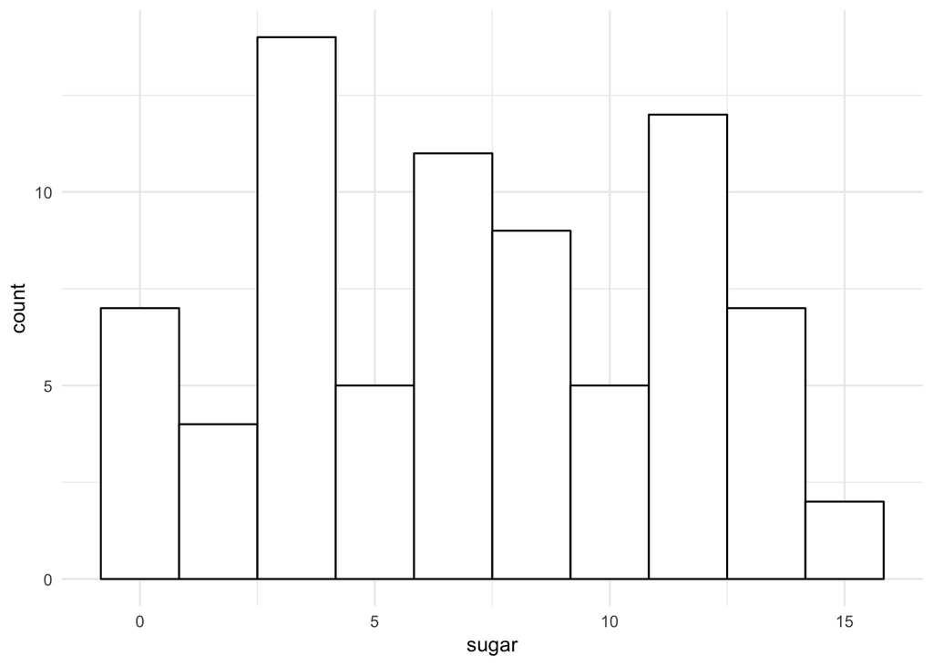

```r
ggplot(cereal, aes(sugar)) +
  geom_histogram(color = "black", fill = "white", bins = 10)
```

Now, compute the standard deviation of the variable `sugar`:

```r
sd(cereal$sugar)
```

```
## [1] 4.378656
```

What are the units of this measurement?

**Answer**: grams

Now, compute the deciles of the variable `score`:

```r
deciles(cereal$score)
```

```
##   0%  10%  20%  30%  40%  50%  60%  70%  80%  90% 100%
## 18.0 28.0 31.0 34.5 37.0 40.0 42.0 48.0 53.0 58.0 84.0
```

What is the value of the 30th percentile. Describe what this means in words:

**Answer**: 34.5. It means that approximately 30% of cereals have an overall score less than 34.5 and 70% have a score greater than 34.5.

Produce a boxplot of score and brand.

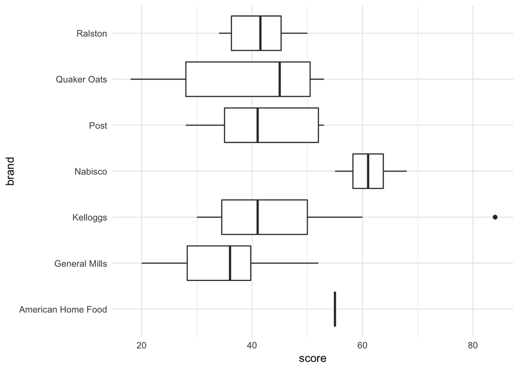

```r
ggplot(cereal, aes(brand, score)) +
  geom_boxplot() +
  coord_flip()
```

Which brand seems to have the healthiest cereals?

**Answer**: Nabisco.

Produce a boxplot of score and shelf.

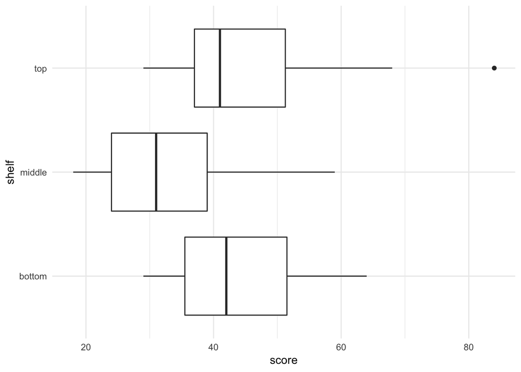

```r
ggplot(cereal, aes(shelf, score)) +
  geom_boxplot() +
  coord_flip()
```

Produce a boxplot of sugar and shelf.

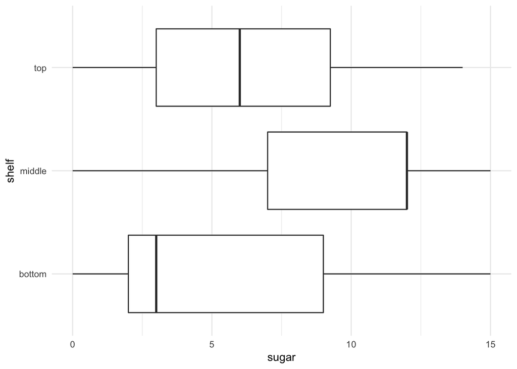

```r
ggplot(cereal, aes(shelf, sugar)) +
  geom_boxplot() +
  coord_flip()
```

If I want a healthy but reasonably sweet cereal which shelf would be the best to look on?

**Answer**: The top and bottom shelves are similarly healthy, but the top has sweeter options, so the top shelf would be your best bet.

## Tea Reviews

Next, we will take another look at a dataset of tea reviews that I used in a previous lecture:

```r
tea <- read_csv("https://statsmaths.github.io/stat_data/tea.csv")
```

With variables: - name: the full name of the tea - type: the type of tea. One of: - black - chai - decaf - flavors - green - herbal - masters - matcha - oolong - pu_erh - rooibos - white - score: user rated score; from 0 to 100 - price: estimated price of one cup of tea - num_reviews: total number of online reviews

Draw a scatterplot with num_reviews (x-axis) against score (y-axis) and add a regression line (recall: `geom_bestfit()`).

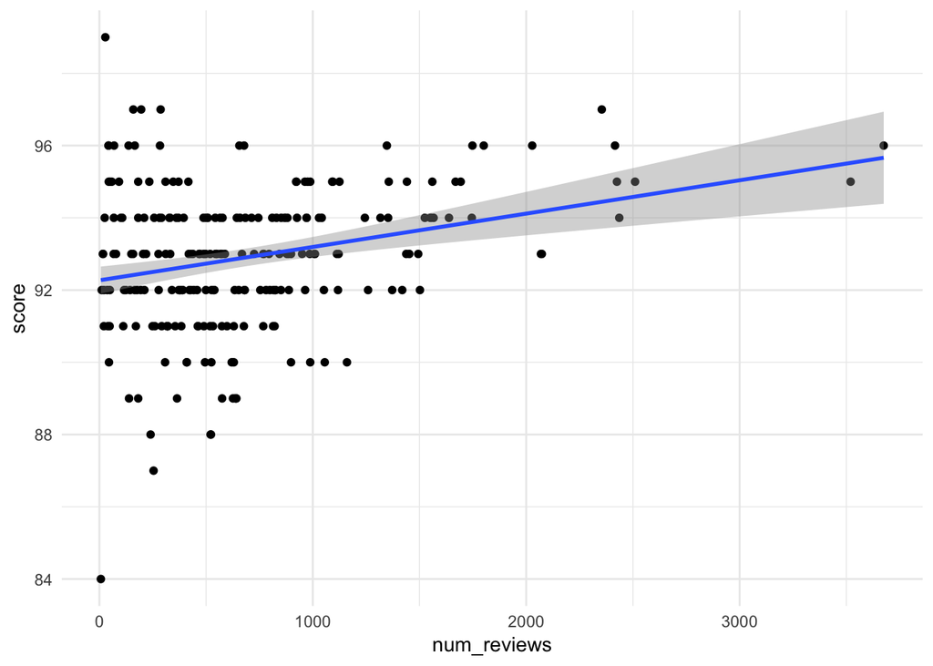

```r
ggplot(tea, aes(num_reviews, score)) +
  geom_point() +
  geom_bestfit()
```

Does the score tend to increase, decrease, or remain the same as the number of reviews increases?

**Answer**: It tends to increase as the number of reviews increases.

Calculate the ventiles of the variable price.

```r
ventiles(tea$price)
```

```
##     0%     5%    10%    15%    20%    25%    30%    35%    40%    45%
##   8.00  10.00  10.00  10.00  10.00  10.00  12.00  12.00  12.00  12.00
##    50%    55%    60%    65%    70%    75%    80%    85%    90%    95%
##  13.00  15.00  15.00  17.00  19.00  20.00  30.00  35.35  49.30  86.75
##   100%
## 196.00
```

What is the 80th percentile? Describe it in words, include the units of the problem in your answer.

**Answer**: The 80th percentile is 30 cents. It means that (roughly) 80% of teas have a price per cup of less than 30 cents and (roughly) 20% have a price greater than 30 cents.

Plot the number of reviews (x-axis) against the score variable. Color the points according to price binned into 5 buckets.

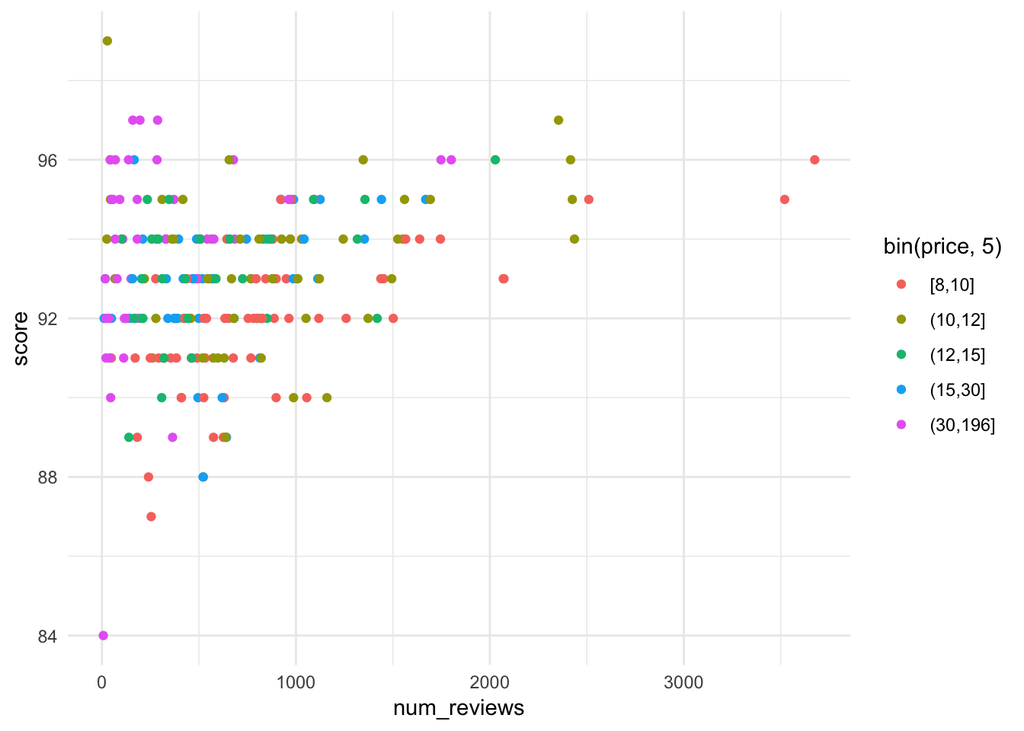

```r
ggplot(tea, aes(num_reviews, score)) +
  geom_point(aes(color = bin(price, 5)))
```

What tends to be true about the number of reviews for the most expensive 20% of teas?

**Answer**: They do not have a lot of reviews, likely because not a lot of people buy such expensive tea.

Create a dataset named `white` that consists of only white teas.

```r
white <- filter(tea, type == "white")
```

Calculate the standard deviation of the price for white teas and the standard deviation of the price for all of the teas.

```r
sd(white$price)
```

```
## [1] 13.59444
```

```r
sd(tea$price)
```

```
## [1] 30.42485
```

Is the variation of the white tea prices smaller, larger, or about the same as the entire dataset?

**Answer**: The variation in price in the white teas is much smaller than that in the entire dataset.

### Group summarize

Now, make use of the group summarize command. Summarize the dataset by the type of tea and save the results as a variable named `tea_type`.

```r
tea_type <- group_summarize(tea, type)
```

Plot the average price (x-axis) against the average score (y-axis) of each type of tea. Make the size of the points proportional to the number of teas in each category and label the points with `geom_text_repel` (it is used like `geom_text` but will produce a better looking output here) using the tea type as the label.

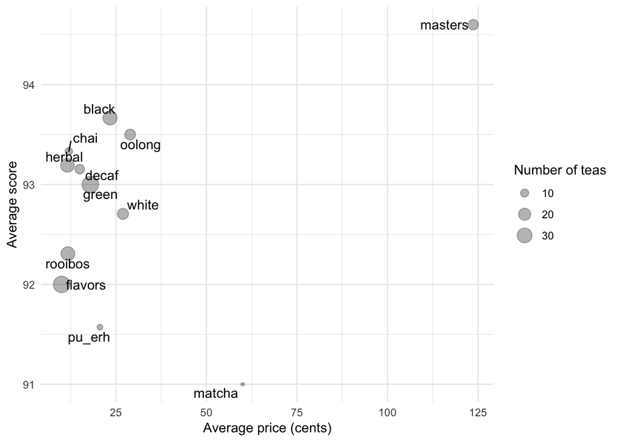

```r
ggplot(tea_type, aes(price_mean, score_mean)) +
  geom_point(aes(size = n), alpha = 0.3) +
  geom_text_repel(aes(label = type)) +
  labs(size = "Number of teas") +
  xlab("Average price (cents)") +
  ylab("Average score")
```

Describe an interesting pattern or set of outliers that you found in the previous plot. This does not need to take more than 1-2 sentences.

**Answer**: The “typical” (at least in the U.S.) black tea has the second highest average score. The two most exotic types, pu-erh and matcha, are the two most scores. Perhaps a result of the unfamiliarity by U.S.-based customers.